# IODS course project

Anton Kunnari

# Introduction to Open Data Science - Course Project

# About the project

Excited about this Open Data Science course!

https://github.com/KunnariA/IODS-project

```r
# This is a so-called "R chunk" where you can write R code.

date()
```

```
## [1] "Fri Dec  4 07:23:49 2020"
```

The text continues here.

# Chapter 2. Regression and model validation

*This week I preprocessed a dataset by selecting a subset og variables and a lot of new variables. I used these in regression model which I then examined with diagnostic plots*

First, importing some necessary R-packages

```r
library(GGally)
library(tidyverse)
```

#### 1.

Let’s read the data.

```r
# Read data
dat <- read.csv("data/learning2014.csv")
```

First, let’s examine the dimensions of the data and the variables it contains.

```r
dim(dat)
```

```
## [1] 166   7
```

```r
names(dat)
```

```
## [1] "gender"   "Age"      "Attitude" "Deep"     "Stra"     "Surf"     "Points"
```

We observe that the data contains 166 observations and 7 variables. These variables are the responders gender and Age, Attitude towards statistics, Deep, Strategic, and Surface approach to learning, and (exam) Points

#### 2.

Then, we’ll examine the data with graphical representation of the distributions and relationships of the variables.

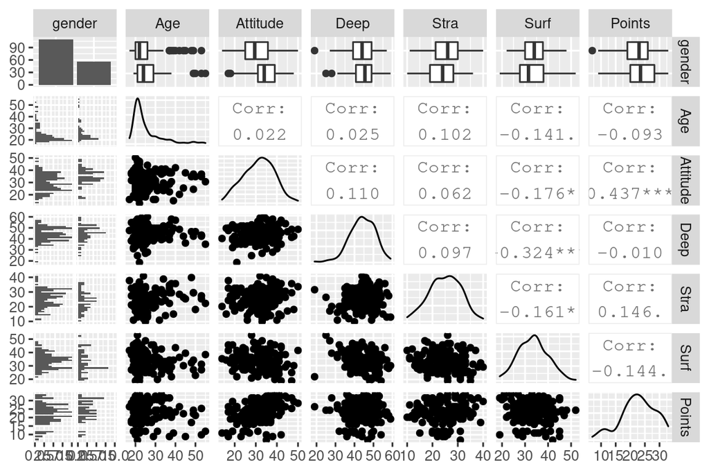

```r
# Graphical examination of the data
dat %>%
  suppressWarnings %>%
  ggpairs
```

The sample seems to be mainly young people. Besides age, the variables look pretty normally distributed. We observe some large correlations between non-demographic variables, like between Attitude and exam points and Surface and Deep approach to learning (negative association).

#### 3.

##### Baseline model

```r
# Let's predict Exam scores by Surf, Deep, and Stra
reg1 <- lm(Points ~ Attitude + Surf + Stra, data=dat)
summary(reg1)
```

```
##
## Call:
## lm(formula = Points ~ Attitude + Surf + Stra, data = dat)
##
## Residuals:
##      Min       1Q   Median       3Q      Max
## -17.1550  -3.4346   0.5156   3.6401  10.8952
##
## Coefficients:
##             Estimate Std. Error t value Pr(>|t|)
## (Intercept) 11.01711    3.68375   2.991  0.00322 **
## Attitude     0.33952    0.05741   5.913 1.93e-08 ***
## Surf        -0.04884    0.06678  -0.731  0.46563
## Stra         0.10664    0.06770   1.575  0.11716
## ---
## Signif. codes:  0 '***' 0.001 '**' 0.01 '*' 0.05 '.' 0.1 ' ' 1
##
## Residual standard error: 5.296 on 162 degrees of freedom
## Multiple R-squared:  0.2074, Adjusted R-squared:  0.1927
## F-statistic: 14.13 on 3 and 162 DF,  p-value: 3.156e-08
```

Attitude is related with exam scores significantly above chance level (t-values and the corresponding t-values). Also, quite obviously the overall model performs significantly better than chance.

The R-squared indicates the proportion of the variance of the dependent variable that is expained by the whole model. In this case the proportion of explained variance is roughly 19%.

Next, let’s sequentially remove non-significant predictors starting with Surf.

```r
# Let's predict Exam scores by Surf, Deep, and Stra
reg2 <- lm(Points ~ Attitude + Stra, data=dat)
summary(reg2)
```

```
##
## Call:
## lm(formula = Points ~ Attitude + Stra, data = dat)
##
## Residuals:
##      Min       1Q   Median       3Q      Max
## -17.6436  -3.3113   0.5575   3.7928  10.9295
##
## Coefficients:
##             Estimate Std. Error t value Pr(>|t|)
## (Intercept)  8.97290    2.39591   3.745  0.00025 ***
## Attitude     0.34658    0.05652   6.132 6.31e-09 ***
## Stra         0.11421    0.06681   1.709  0.08927 .
## ---
## Signif. codes:  0 '***' 0.001 '**' 0.01 '*' 0.05 '.' 0.1 ' ' 1
##
## Residual standard error: 5.289 on 163 degrees of freedom
## Multiple R-squared:  0.2048, Adjusted R-squared:  0.1951
## F-statistic: 20.99 on 2 and 163 DF,  p-value: 7.734e-09
```

Lets then remove Stra and we’ll likely arrive to our final model:

```r
# Let's predict Exam scores by Surf, Deep, and Stra
reg3 <- lm(Points ~ Attitude, data=dat)
summary(reg3)
```

```
##
## Call:
## lm(formula = Points ~ Attitude, data = dat)
##
## Residuals:
##      Min       1Q   Median       3Q      Max
## -16.9763  -3.2119   0.4339   4.1534  10.6645
##
## Coefficients:
##             Estimate Std. Error t value Pr(>|t|)
## (Intercept) 11.63715    1.83035   6.358 1.95e-09 ***
## Attitude     0.35255    0.05674   6.214 4.12e-09 ***
## ---
## Signif. codes:  0 '***' 0.001 '**' 0.01 '*' 0.05 '.' 0.1 ' ' 1
##
## Residual standard error: 5.32 on 164 degrees of freedom
## Multiple R-squared:  0.1906, Adjusted R-squared:  0.1856
## F-statistic: 38.61 on 1 and 164 DF,  p-value: 4.119e-09
```

#### 4.

Now we have a model where we predict exam scores with Attitude towards statistics. The model indicates that increasing this attitude variable by one point, predicted exam score increases by .35. This relationship between the variables accounts for roughly 19% of the variation in exam scores.

#### 5.

Finally, let’s check the model assumptions using graphical methods. The model assumes that 1) There is no relationship (even non-linear) between the fitted values and residuals, 2) normality of the model residuals, and 3) no outliers (very influential observations with deviating patterns).

First let’s check the assumption that there is no systematic patterns between predicted values and model residuals.

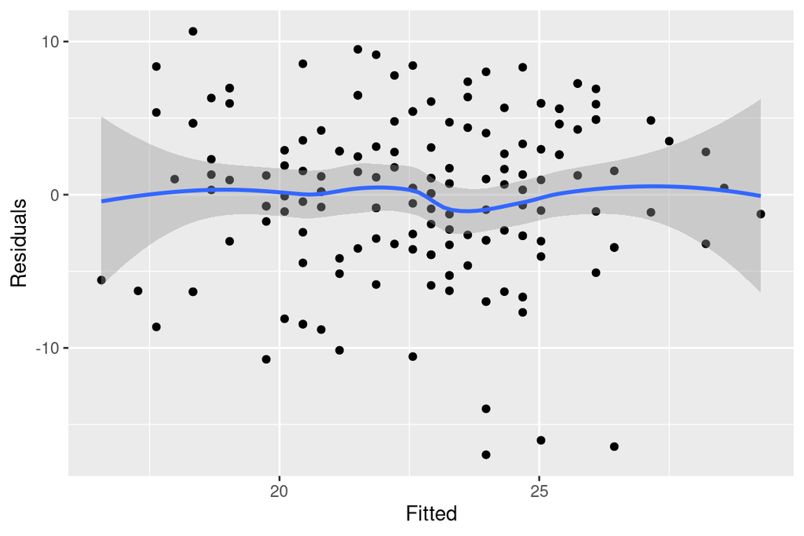

```r
res.dat <- data.frame(fitted = reg3$fitted.values, residuals = reg3$residuals)

ggplot(res.dat, aes(x = fitted, y = residuals)) +
  geom_point() +
  geom_smooth() +
  xlab("Fitted") +
  ylab("Residuals")
```

The pattern looks pretty random to me, so the assumption of independence of predictions and residuals seems to hold. Next let’s examine whether the assumotion of normality of residuals holds by producing a qqplot.

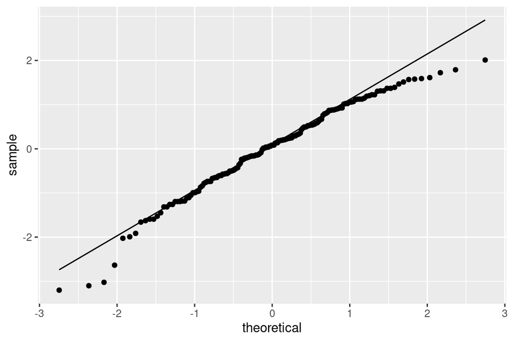

```r
ggplot(res.dat, aes(sample = scale(residuals))) +
  geom_qq() +
  geom_qq_line()
```

The obsevations mostly fall into the qq-line, except in the distribution tails. This means that the distribution of residuals is *roughly* normal. Finally let’s examine potentially influetial observations (outliers) with residuals vs leverage plot.

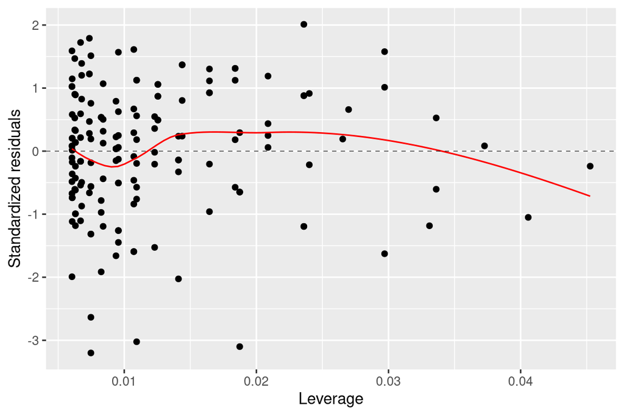

```r
res.dat$leverage <- influence(reg3)$hat

ggplot(res.dat, aes(x=leverage, y = scale(residuals))) +
  geom_point() +
  geom_smooth(method="loess", se=FALSE, color="red", size=0.5) +
  geom_hline(yintercept = 0, size=0.2, lty="dashed") +
  xlab("Leverage") +
  ylab("Standardized residuals")
```

There seems to be no major outliers.

# Chapter 3. Logistic regression

*This week I preprocessed a dataset by merging two datasets together and then used this in a logistic regression model*

```r
library(GGally)
library(tidyverse)
```

#### 2.

Let’s open the data created in the first assignments of this week’s exercises.

```r
alc <- read.csv("data/student_alc.csv")
var_names <- names(alc)
```

This data contains survey responses from Portugese students in secondary education. The description of the variables is available at: https://archive.ics.uci.edu/ml/datasets/Student+Performance.

The full list of variables in the data: X, school, sex, age, address, famsize, Pstatus, Medu, Fedu, Mjob, Fjob, reason, nursery, internet, guardian, traveltime, studytime, failures, schoolsup, famsup, paid, activities, higher, romantic, famrel, freetime, goout, Dalc, Walc, health, absences, G1, G2, G3, alc_use, high_use.

#### 3.

Next, let’s predict **high_use** of alcohol with logistic regression by some other variables. Gender (**sex**) might be relevant here as I would imagine men to consume more alcohol. Going out with friends (**goout**) also sounds like it could be positively related to alcohol consumption. Third, I would imagine children from broken families where parents live apart (**Pstatus**) to consume more alcohol. Finally, and related to the former, the quality of family relationships (**famrel**) likely predict less alcohol consumption.

#### 4.

Most of the variables are categorical, so below are the class frequencies for those.

```r
# High alcohol use
table(alc$high_use)
```

```
##
## FALSE  TRUE
##   270   112
```

```r
# Gender (F = Female, M = Male)
table(alc$sex)
```

```
##
##   F   M
## 198 184
```

```r
# Parent status (A = Apart, T = Together)
table(alc$Pstatus)
```

```
##
##   A   T
##  38 344
```

While the gender ratio is close to 50/50, the other two variables are more skewed: there was over two times more low alcohol-consumin individuals compared to high consumption, and nine times more together-living parents.

Below is some graphical examination of the selected variables and their relationships. Warning: the graphic below is very messy.

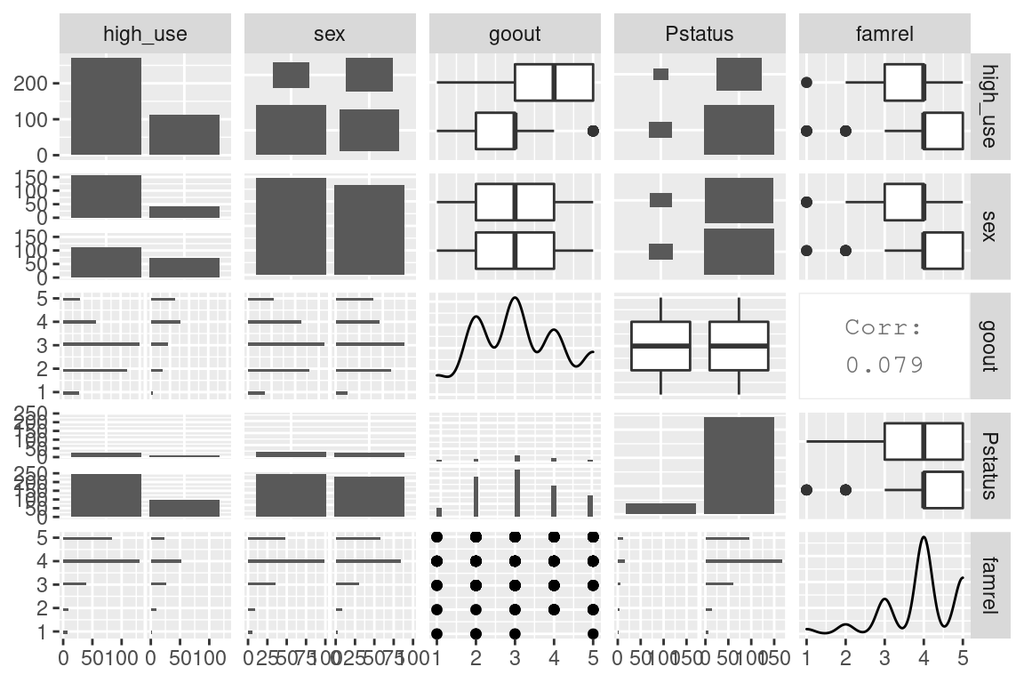

```r
alc %>%
  dplyr::select(high_use, sex, goout, Pstatus, famrel) %>%
  ggpairs
```

The relevant parts are the first row and the first column, which describe the relationships between the predicted variable and the predictors. We observe a difference in bar heights in the first panel of the second row suggesting different drinking pattern in men compared to women. Below in the first panel of the third row, lower values of “going out with friends” are more common in low alcohol consumption category compared to high consumption where the most common values are the greater ones. Relationship between parental living status and alcohol consumption is very difficult to appraise visually because of the very low amount of apart-living parents. Finally, while the higher values of family relationship quality are common in both alcohol consumption group, highest values seem to be relatively more common in low consumption group.

#### 5.

```r
res.log <- glm(high_use ~ sex + goout + Pstatus + famrel, data = alc, family="binomial")
summary(res.log)
```

```
##
## Call:
## glm(formula = high_use ~ sex + goout + Pstatus + famrel, family = "binomial",
##     data = alc)
##
## Deviance Residuals:
##     Min       1Q   Median       3Q      Max
## -1.5729  -0.7726  -0.5065   0.8281   2.5783
##
## Coefficients:
##             Estimate Std. Error z value Pr(>|z|)
## (Intercept)  -2.1078     0.7135  -2.954 0.003135 **
## sexM          0.9591     0.2542   3.774 0.000161 ***
## goout         0.8055     0.1217   6.619 3.62e-11 ***
## PstatusT     -0.1196     0.4139  -0.289 0.772624
## famrel       -0.4663     0.1384  -3.370 0.000753 ***
## ---
## Signif. codes:  0 '***' 0.001 '**' 0.01 '*' 0.05 '.' 0.1 ' ' 1
##
## (Dispersion parameter for binomial family taken to be 1)
##
##     Null deviance: 462.21  on 381  degrees of freedom
## Residual deviance: 387.46  on 377  degrees of freedom
## AIC: 397.46
##
## Number of Fisher Scoring iterations: 4
```

As predicted, male gender predicts high alcohol use as well as (frequency of?) going out with friends. Contra to prediction, no evidence was found for higher alcohol use when parents live apart. The quality of family relationships was inversely related to alcohol consumption. Below are the model coefficients as odds ratios.

```r
ecoef <- exp(coef(res.log))
CI <- exp(confint(res.log))

tab <- cbind(CI[,1], ecoef, CI[,2])
tab <- round(tab, 2)
colnames(tab) <- c("CI low", "OR", "CI high")
tab
```

```
##             CI low   OR CI high
## (Intercept)   0.03 0.12    0.48
## sexM          1.59 2.61    4.33
## goout         1.78 2.24    2.86
## PstatusT      0.40 0.89    2.05
## famrel        0.48 0.63    0.82
```

These model coefficients are interpreted as follows: the “baseline” odds ratio is .12 which means that high alcohol consumption is quite unlikely before accounting for the predictor variables. An odds ratio of .12 translates to 11% chance of high consumption. The other coefficients tell by which factor this baseline chance is multiplied. For males, odds for high consumption is increased by factor of 2.61. For numeric variable **goout** an increase of 1 unit increases the odds for high consumption by factor of 2.24 and an unit increase in **famrel** decreses these odds by factor of .63. **Pstatus** was not a significant predictor as its confidence interval includes 1, so we don’t interpret it here.

#### 6.

Below first the probabilities for high alcohol consumption are computed from the model, and then converted to dichotomous TRUE / FALSE predictions if this probability is over 50% for any given person. These dichotomous predictions are then cross-tabulated with actual data for evaluation of prediction accuracy.

```r
predictions <- predict(res.log, type="response")
cat_pred <- ifelse(predictions > 0.5, 1, 0)

tab <- table(alc$high_use, cat_pred)
colnames(tab) <- c(FALSE, TRUE)
tab
```

```
##        cat_pred
##         FALSE TRUE
##   FALSE   251   19
##   TRUE     62   50
```

From this table we can compute the percentages for correct and incorrect predictions. Correct predictions those with the same row and column variables (both TRUE or both FALSE) are incorrect predictions if those conflict. The predictions contain 251 true negatives: when low alcohol consumption (row FALSE) is correctly predicted as such. They also contain 50 true positives: when high consumption (row TRUE) is predicted as high. Together these make up 301 correct predictions. When prediction is TRUE, but the actual value is false, this is a false positive prediction. There are 19 cases where an individual was predicted to have high consumption (column TRUE) when this was not actually the case. Likewise, in 62 cases alcohol consumption was predicted to be low (column FALSE), but was actually high.

These frequencies can be used to compute the accuracy of the model:

```r
(251 + 50) / (251 + 50 + 19 + 62)
```

```
## [1] 0.7879581
```

Thus the model has roughly 79% “hit-rate”, which is substantially higher than simply guessing with 50/50 odds.

# Chapter 4. Clustering

**This week’s exercise included joining two datasets by identifier variables, conducting linear discriminant analysis and k-means clustering**

```r
library(GGally)
library(MASS)
library(tidyverse)
```

## 1.

Here we explore the **Boston** data from **MASS** package. First we copy the dataframe to new variable **boston** to make accessing it easier.

```r
boston <- MASS::Boston
```

## 2. Data examination

First, a quick examination of the structure and contents of the data.

```r
# Dimensions of the data
dims <- dim(boston)

# Varibales of the data
var_names <- names(boston)
```

The data has 506 observations and 14 variables. The variables contain information (copied from data documentation) about: per capita crime rate by town (**crim**), proportion of residential land zoned for lots over 25,000 sq.ft (**zn**), proportion of non-retail business acres per town (**indus**), Charles River dummy variable (= 1 if tract bounds river; 0 otherwise, **chas**), nitrogen oxides concentration (parts per 10 million; **nox**), average number of rooms per dwelling (**rm**), proportion of owner-occupied units built prior to 1940 (**age**), weighted mean of distances to five Boston employment centres (**dis**), index of accessibility to radial highways (**rad**), full-value property-tax rate per $10,000 (**tax**), pupil-teacher ratio by town (**ptratio**), 1000(Bk - 0.63)^2 where Bk is the proportion of blacks by town (**black**), lower status of the population (percent; **lstat**), median value of owner-occupied homes in $1000s (**medv**).

## 3. Graphical overview of the data

Pairwise scatterplots for all the variables is presented below.

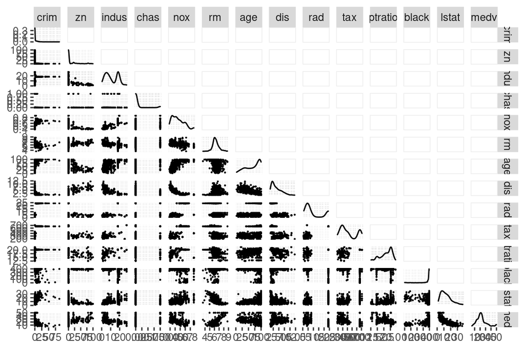

```r
GGally::ggpairs(boston,
                lower = list(continuous = wrap("points", size=0.1)),
                upper = list(continuous = wrap("cor", size=0)))
```

On the density plots on the plot diagonal, we see the distributions of the variables. Some of these are super skewed, resembling exponential or power-law distribution. Others look remotely or close to normal. Some seem to be double-peaked. The relationships between the variables are too numerous to describe in detail here, but we see many interesting patterns. Some resemble linear relationships but many don’t, casting doubt on using standard linear methods for these data.

## 4. Data transformation

Next, we’ll do z-transformation for each variable in the data, and save the resulting dataframe to a new object **boston_z**. Below is a brief summary of the standardized variables, with main value being infomation about quantile thresholds that describe the shapes of the distributions. In some variables these are very asymmetrical in relation to median, indicating great skewness already seen in density plots. Some max values are also ridiculously huge (like in **crim**) considering these are z-scaled variables. This means that the variable has at least one very influential observation.

```r
boston_z <- scale(boston)
boston_z <- as.data.frame(boston_z)
summary(boston_z)
```

```
##       crim                 zn               indus              chas
##  Min.   :-0.419367   Min.   :-0.48724   Min.   :-1.5563   Min.   :-0.2723
##  1st Qu.:-0.410563   1st Qu.:-0.48724   1st Qu.:-0.8668   1st Qu.:-0.2723
##  Median :-0.390280   Median :-0.48724   Median :-0.2109   Median :-0.2723
##  Mean   : 0.000000   Mean   : 0.00000   Mean   : 0.0000   Mean   : 0.0000
##  3rd Qu.: 0.007389   3rd Qu.: 0.04872   3rd Qu.: 1.0150   3rd Qu.:-0.2723
##  Max.   : 9.924110   Max.   : 3.80047   Max.   : 2.4202   Max.   : 3.6648
##       nox                rm               age               dis
##  Min.   :-1.4644   Min.   :-3.8764   Min.   :-2.3331   Min.   :-1.2658
##  1st Qu.:-0.9121   1st Qu.:-0.5681   1st Qu.:-0.8366   1st Qu.:-0.8049
##  Median :-0.1441   Median :-0.1084   Median : 0.3171   Median :-0.2790
##  Mean   : 0.0000   Mean   : 0.0000   Mean   : 0.0000   Mean   : 0.0000
##  3rd Qu.: 0.5981   3rd Qu.: 0.4823   3rd Qu.: 0.9059   3rd Qu.: 0.6617
##  Max.   : 2.7296   Max.   : 3.5515   Max.   : 1.1164   Max.   : 3.9566
##       rad               tax             ptratio            black
##  Min.   :-0.9819   Min.   :-1.3127   Min.   :-2.7047   Min.   :-3.9033
##  1st Qu.:-0.6373   1st Qu.:-0.7668   1st Qu.:-0.4876   1st Qu.: 0.2049
##  Median :-0.5225   Median :-0.4642   Median : 0.2746   Median : 0.3808
##  Mean   : 0.0000   Mean   : 0.0000   Mean   : 0.0000   Mean   : 0.0000
##  3rd Qu.: 1.6596   3rd Qu.: 1.5294   3rd Qu.: 0.8058   3rd Qu.: 0.4332
##  Max.   : 1.6596   Max.   : 1.7964   Max.   : 1.6372   Max.   : 0.4406
##      lstat              medv
##  Min.   :-1.5296   Min.   :-1.9063
##  1st Qu.:-0.7986   1st Qu.:-0.5989
##  Median :-0.1811   Median :-0.1449
##  Mean   : 0.0000   Mean   : 0.0000
##  3rd Qu.: 0.6024   3rd Qu.: 0.2683
##  Max.   : 3.5453   Max.   : 2.9865
```

Below, a categorical variable **crimeQ** is created by using quantiles as break-points.

```r
# Compute quantiles for variable crim
q <- quantile(boston_z$crim)

# Create new categorical variable for crime quantiles
# Drop the old crim variable
boston_z <- boston_z %>%
  mutate(crimeQ = case_when(crim < q[2] ~ 1,
                            crim >= q[2] & crim < q[3] ~ 2,
                            crim >= q[3] & crim < q[4] ~ 3,
                            crim >= q[4] ~ 4)) %>%
  dplyr::select(-crim)
```

Finally, divide the modified data into training data and test data.

```r
# N needed for training data
n_train <- round(0.8*dim(boston_z)[1])

# Index vector for training data
i_train <- sample(1:dim(boston)[1], n_train)

# Use the vector created above to split data into training and test data
boston_train <- boston_z[i_train,]
boston_test <- boston_z[-i_train,]
```

## 5.

Let’s computationally create the formula for discriminant analysis. It’s less tedious this way.

```r
predictors <- paste(names(boston_train[,-14]), collapse="+")
formula <- as.formula(paste("crimeQ", predictors, sep="~"))
print(formula)
```

```
## crimeQ ~ zn + indus + chas + nox + rm + age + dis + rad + tax +
##     ptratio + black + lstat + medv
```

Using this formula and the transformed data, let’s do linear discriminant analysis, where quantilized crime rate is predicted by all other variables. We know quantilized variables should have perfectly even 25/25/25/25 distribution, so let’s use these as priors in the model to account for any imperfections in randomization.

```r
res.lda <- MASS::lda(formula,
                     data=boston_train,
                     prior=c(0.25, 0.25, 0.25, 0.25))
```

Next, let’s draw a biplot, ggplot style.

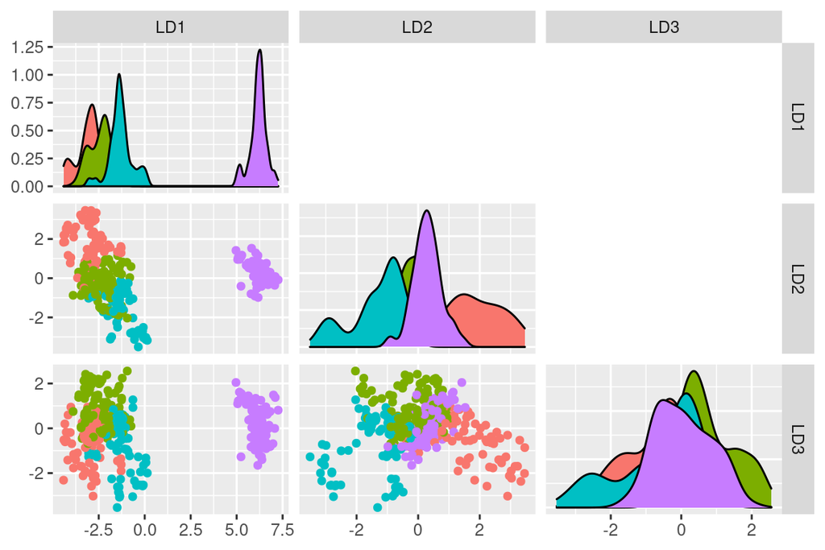

```r
# Predictions from LDA for training data
preds.lda <- predict(res.lda)

dat <- as.data.frame(cbind(preds.lda$class, preds.lda$x))
names(dat) <- c("class", "LD1", "LD2", "LD3")
dat$class <- as.factor(dat$class)

dat %>%
  ggpairs(columns = 2:4, aes(color=class), upper="blank")
```

## 6. Cross-validation

The real categorical variable **crimeQ** is removed from the test data, and saved as a separate object “correct”.

```r
# Make categorical crime variable a separate object
correct <- boston_test$crimeQ

# Remove the categorical crime variable from test data
boston_test <- boston_test %>%
  dplyr::select(-crimeQ)
```

Create predicted **crimeQ**-categories for the test data using the LDA model specified above. The predictions of this model are then cross-tabulated with real category values to assess the predictive accuracy of the model.

```r
preds <- predict(res.lda, newdata = boston_test)
prediction <- preds$class

tab <- table(prediction, correct)
tab
```

```
##           correct
## prediction  1  2  3  4
##          1 15  7  1  0
##          2 10 18  6  0
##          3  0  3 17  0
##          4  0  0  1 23
```

The correct predictions lie on the diagonal. We see that majority of the observations fall there, with several being just over or under diagonal. This means that the prediction errors are never completely opposite from the real value (for example category value 1 is predicted as 4 or vice versa). The prediction errors seem somewhat symmetrical regarding the category number, with rather similar number of “over- and underpredicted” observations.

By dividing the sum of numbers on the diagonal by the sum of all table values, we get the predictive accuracy of the model: the proportion of correctly predicted categories.

```r
sum(diag(tab)) / sum(tab)
```

```
## [1] 0.7227723
```

## 7. K-means clustering

Euclidean distances for scaled Boston data

```r
boston_z <- scale(MASS::Boston)

dist_mat <- dist(boston_z, method="euclidean")
summary(dist_mat)
```

```
##    Min. 1st Qu.  Median    Mean 3rd Qu.    Max.
##  0.1343  3.4625  4.8241  4.9111  6.1863 14.3970
```

K-means clustering with 5 clusters.

```r
k.res <- kmeans(boston_z, centers = 5)
```

Evaluation of proper number of clusters

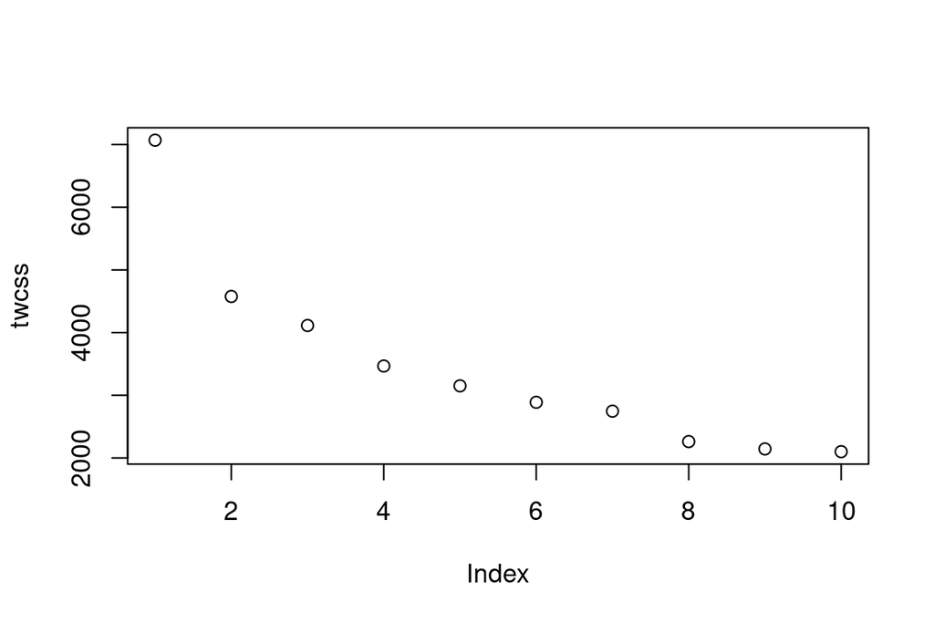

```r
k_max = 10

# Code from DataCamp
twcss <- sapply(1:k_max, function(k){kmeans(boston_z, k)$tot.withinss})
plot(twcss)
```

Greatest drop in total within category SS occurs at 2 clusters. This seems the appropriate number.

## Bonus

Below the data is first clustered with k-means with 5 clusters. Then LDA is fitted for the data using the created clusters as target categories. Created clusters and the categories predicted by LDA is presented in cross-tabulation below.

```r
# New k-means clustering with 5 clusters
k.res2 <- kmeans(boston_z, centers = 5)

predictors <- paste(names(as.data.frame(boston_z)), collapse="+")
formula <- as.formula(paste("k.res2$cluster", predictors, sep="~"))

lda.res2 <- lda(k.res2$cluster ~ boston_z)
preds2 <- predict(lda.res2)$class

tab <- table(preds2, k.res2$cluster)
tab
```

```
##
## preds2   1   2   3   4   5
##      1 126   0   0   0   0
##      2   0  51   0   2   0
##      3   0   0  48   1   0
##      4   0   6   0 117  13
##      5   4   0   1   6 131
```

Most values fall on the diagonal, so prediction error seems to be very rare using this type of analysis. Finally the model accuracy (of LDA using kmeans as criterion) is calculated in same way as above.

```r
sum(diag(tab)) / sum(tab)
```

```
## [1] 0.9347826
```

The model (LDA) has almost perfect accuracy predicting the categories created by k-means algorithm.

# Chapter 5 Dimensionality reduction

```r
library(FactoMineR)
library(GGally)
library(tidyverse)
```

## 1. Overview of the data

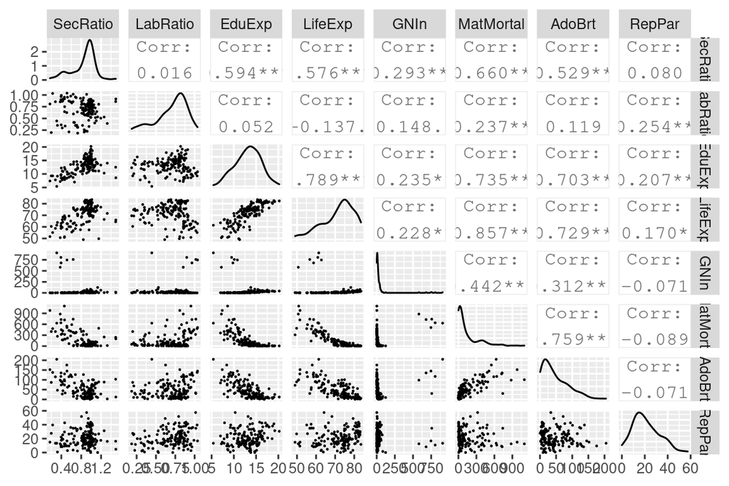

```r
# Read data
dat <- read.csv("data/human.csv", row.names = "X")

GGally::ggpairs(dat, lower = list(continuous = wrap("points", size=0.1)))
```

Some distributions are very skewed, resembling exponential or power-law distribution. Others look somewhat normal. Most correlations between the variables are notable, with some exeptions being LabRatio~SecRatio, EduExp~LabRatio and AdoBrt~RepPar.

## 2. Principal components analysis

Let’s do principal components analysis to the human data.

```r
res.pca <- princomp(dat)
summary(res.pca)
```

```
## Importance of components:
##                            Comp.1     Comp.2      Comp.3       Comp.4
## Standard deviation     226.103260 120.524383 26.31142349 11.415380196
## Proportion of Variance   0.768889   0.218474  0.01041211  0.001959886
## Cumulative Proportion    0.768889   0.987363  0.99777513  0.999735011
##                              Comp.5       Comp.6       Comp.7       Comp.8
## Standard deviation     3.8726938744 1.5996468715 1.918696e-01 1.593393e-01
## Proportion of Variance 0.0002255674 0.0000384856 5.536845e-07 3.818526e-07
## Cumulative Proportion  0.9999605789 0.9999990645 9.999996e-01 1.000000e+00
```

```r
res.pca$loadings
```

```
##
## Loadings:
##           Comp.1 Comp.2 Comp.3 Comp.4 Comp.5 Comp.6 Comp.7 Comp.8
## SecRatio                                             0.690  0.723
## LabRatio                                             0.722 -0.691
## EduExp                                 0.191  0.980
## LifeExp                                0.976 -0.194
## GNIn      -0.398  0.917
## MatMortal -0.907 -0.392  0.152
## AdoBrt    -0.134        -0.988
## RepPar                          0.996
##
##                Comp.1 Comp.2 Comp.3 Comp.4 Comp.5 Comp.6 Comp.7 Comp.8
## SS loadings     1.000  1.000  1.000  1.000  1.000  1.000  1.000  1.000
## Proportion Var  0.125  0.125  0.125  0.125  0.125  0.125  0.125  0.125
## Cumulative Var  0.125  0.250  0.375  0.500  0.625  0.750  0.875  1.000
```

The first component captures ~77% of the variability, and the second 22%. The rest are negligible. The biplot between 1st and 2nd PC is presented below.

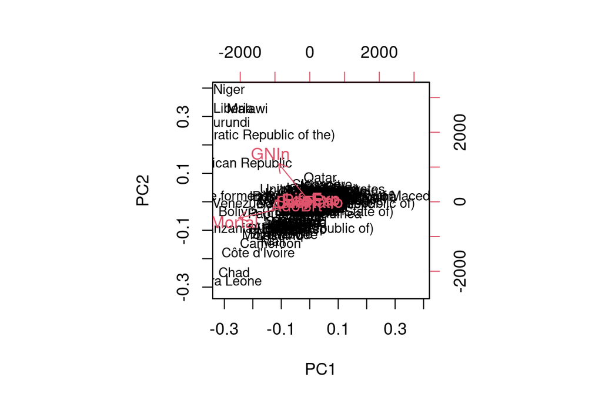

```r
biplot(res.pca, cex = c(0.8, 1), xlab="PC1", ylab = "PC2")
```

## 3. Standaridzed data

Next we do the same thing as above, but with standardized data

```r
# Standardize the data
dat_z <- scale(dat)

# Principal component analysiks
res.pca2 <- princomp(dat_z)
summary(res.pca2)
```

```
## Importance of components:
##                          Comp.1   Comp.2    Comp.3    Comp.4     Comp.5
## Standard deviation     1.990068 1.145425 0.9406608 0.8524938 0.68677519
## Proportion of Variance 0.498240 0.165058 0.1113189 0.0914293 0.05933789
## Cumulative Proportion  0.498240 0.663298 0.7746169 0.8660462 0.92538411
##                            Comp.6     Comp.7     Comp.8
## Standard deviation     0.53072986 0.46343833 0.31088801
## Proportion of Variance 0.03543643 0.02702009 0.01215936
## Cumulative Proportion  0.96082054 0.98784064 1.00000000
```

```r
res.pca2$loadings
```

```
##
## Loadings:
##           Comp.1 Comp.2 Comp.3 Comp.4 Comp.5 Comp.6 Comp.7 Comp.8
## SecRatio   0.377                0.377  0.804  0.199         0.131
## LabRatio          0.717         0.582 -0.267        -0.242
## EduExp     0.433  0.180  0.186        -0.182 -0.380  0.746 -0.105
## LifeExp    0.452         0.193 -0.206 -0.103 -0.365 -0.444  0.612
## GNIn      -0.225  0.194  0.847 -0.343  0.186  0.112        -0.163
## MatMortal -0.470  0.121                       0.156  0.422  0.748
## AdoBrt    -0.427        -0.121         0.410 -0.790
## RepPar            0.628 -0.428 -0.598  0.190  0.141
##
##                Comp.1 Comp.2 Comp.3 Comp.4 Comp.5 Comp.6 Comp.7 Comp.8
## SS loadings     1.000  1.000  1.000  1.000  1.000  1.000  1.000  1.000
## Proportion Var  0.125  0.125  0.125  0.125  0.125  0.125  0.125  0.125
## Cumulative Var  0.125  0.250  0.375  0.500  0.625  0.750  0.875  1.000
```

And the corresponding biplot:

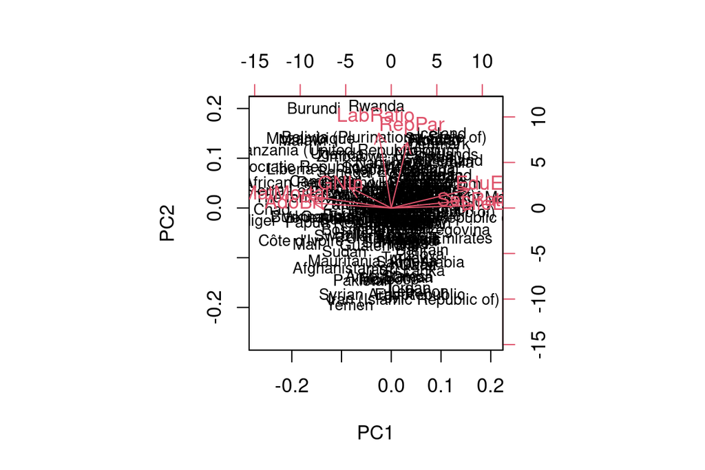

```r
biplot(res.pca2, cex = c(0.8, 1), xlab="PC1", ylab = "PC2")
```

## 4. Interpretation

In the first analysis (without standardization) the first component explains majority of variance. However, only few variables load on this component, and maternal mortality loads on the component very strongly. GNI variable loads on the second component very strongly. It almost seems that each component roughly corresponds to each variable in the data

In the latter results, both variance explained and variable loadings is spread bit more evenly across components. I guess this has something to do with the fact that maternal mortality had the greatest variance in the original data, and thus the corresponding component explains the most variance simply because of that. Now when variables are standardized, unequal variances do not confound the analysis anymore.

## 5. Multiple Correspondence Analysis

Couldn’t get this to work.

# Chapter 6. Analysis of longitudinal data

```r
library(patchwork)
library(tidyverse)
```

## 1. Read the data.

Read the data from data wrangling exercise and re-factor categorical variables.

```r
BPRS_long <- read.csv("data/BPRS_long.csv")
RATS_long <- read.csv("data/RATS_long.csv")

BPRS_long <- BPRS_long %>%
  dplyr::mutate(subject = as.factor(subject),
                treatment = as.factor(treatment),
                week = as.factor(week))

RATS_long <- RATS_long %>%
  dplyr::mutate(ID = as.factor(ID),
                Group = as.factor(Group),
                week = as.factor(week))
```

Visualize the response patterns of each respondent.

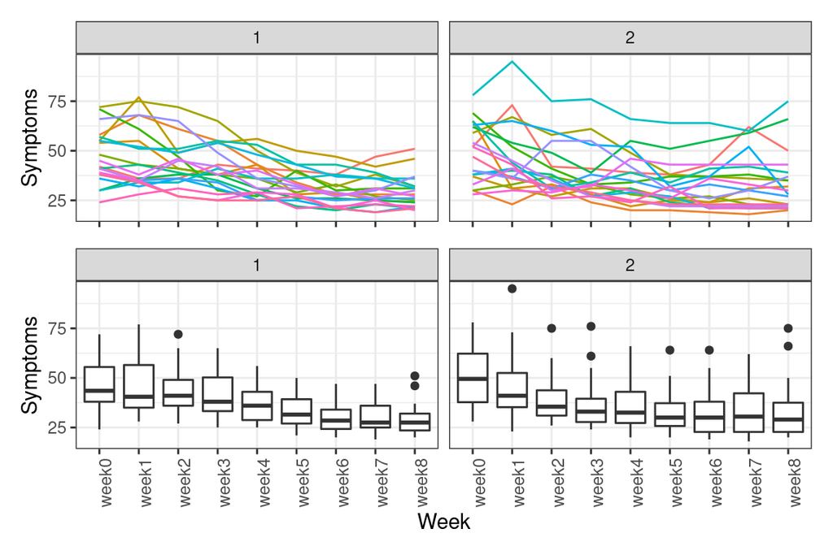

```r
g1 <- ggplot(BPRS_long, aes(x = week, y = value, group=subject, color=subject)) +
  geom_line() +
  facet_wrap(~treatment) +
  xlab("Week") +
  ylab("Symptoms") +
  theme_bw() +
  theme(legend.position = "none",
        axis.text.x = element_blank(),
        axis.title.x = element_blank()
        )
g2 <- ggplot(BPRS_long, aes(x = week, y = value)) +
  geom_boxplot() +
  facet_wrap(~treatment) +
  xlab("Week") +
  ylab("Symptoms") +
  theme_bw() +
  theme(legend.position = "none",
        axis.text.x = element_text(angle=90))

g1 / g2
```

And for the RATS-data:

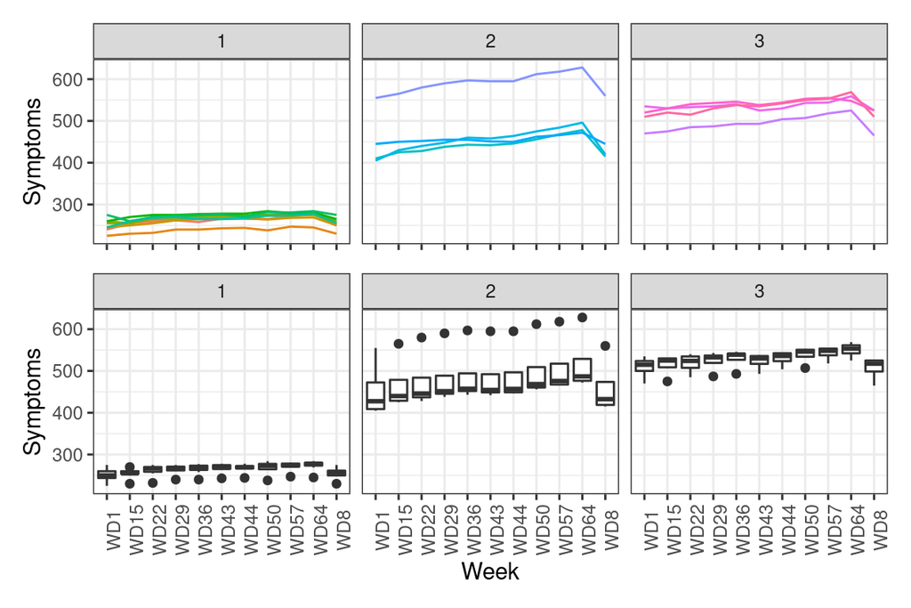

```r
g1 <- ggplot(RATS_long, aes(x = week, y = value, group=ID, color=ID)) +
  geom_line() +
  facet_wrap(~Group) +
  xlab("Week") +
  ylab("Symptoms") +
  theme_bw() +
  theme(legend.position = "none",
        axis.text.x = element_blank(),
        axis.title.x = element_blank()
        )
g2 <- ggplot(RATS_long, aes(x = week, y = value)) +
  geom_boxplot() +
  facet_wrap(~Group) +
  xlab("Week") +
  ylab("Symptoms") +
  theme_bw() +
  theme(legend.position = "none",
        axis.text.x = element_text(angle=90))

g1 / g2
```

Standardize the datasets so that each weeks values are z-transformed independently from each other.

```r
BPRS_long_z <- BPRS_long %>%
  group_by(week) %>%
  mutate(value = scale(value)) %>%
  ungroup()

RATS_long_z <- RATS_long %>%
  group_by(week) %>%
  mutate(value = scale(value)) %>%
  ungroup()
```

Visualization for standardized data.

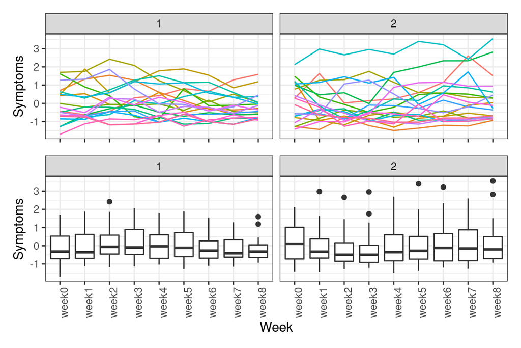

```r
g1 <- ggplot(BPRS_long_z, aes(x = week, y = value, group=subject, color=subject)) +
  geom_line() +
  facet_wrap(~treatment) +
  xlab("Week") +
  ylab("Symptoms") +
  theme_bw() +
  theme(legend.position = "none",
        axis.text.x = element_blank(),
        axis.title.x = element_blank()
        )
g2 <- ggplot(BPRS_long_z, aes(x = week, y = value)) +
  geom_boxplot() +
  facet_wrap(~treatment) +
  xlab("Week") +
  ylab("Symptoms") +
  theme_bw() +
  theme(legend.position = "none",
        axis.text.x = element_text(angle=90))

g1 / g2
```

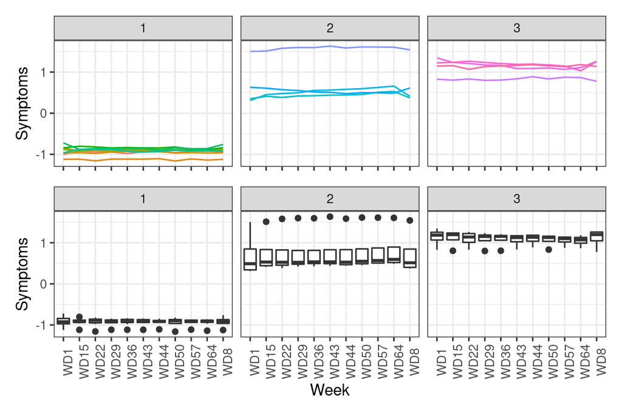

```r
g1 <- ggplot(RATS_long_z, aes(x = week, y = value, group=ID, color=ID)) +
  geom_line() +
  facet_wrap(~Group) +
  xlab("Week") +
  ylab("Symptoms") +
  theme_bw() +
  theme(legend.position = "none",
        axis.text.x = element_blank(),
        axis.title.x = element_blank()
        )
g2 <- ggplot(RATS_long_z, aes(x = week, y = value)) +
  geom_boxplot() +
  facet_wrap(~Group) +
  xlab("Week") +
  ylab("Symptoms") +
  theme_bw() +
  theme(legend.position = "none",
        axis.text.x = element_text(angle=90))

g1 / g2
```

## Summary method

Let’s produce summary tables from original datasets.

```r
BPRSS <- BPRS_long %>%
  group_by(treatment, week) %>%
  summarise(mean = mean(value),
            sd = sd(value),
            n = length(value),
            se = sd / sqrt(n) ) %>%
  ungroup()
RATSS <- RATS_long %>%
  group_by(Group, week) %>%
  summarise(mean = mean(value),
            sd = sd(value),
            n = length(value),
            se = sd / sqrt(n) ) %>%
  ungroup()
```

Summary graph for BPRS-data.

```
## geom_path: Each group consists of only one observation. Do you need to adjust
## the group aesthetic?
```

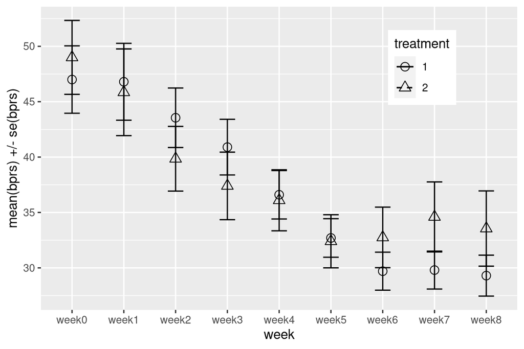

```r
ggplot(BPRSS, aes(x = week, y = mean, linetype = treatment, shape = treatment)) +
  geom_line() +
  scale_linetype_manual(values = c(1,2)) +
  geom_point(size=3) +
  scale_shape_manual(values = c(1,2)) +
  geom_errorbar(aes(ymin=mean-se, ymax=mean+se, linetype="1"), width=0.3) +
  theme(legend.position = c(0.8,0.8)) +
  scale_y_continuous(name = "mean(bprs) +/- se(bprs)")
```

Summary graph for RATS-data

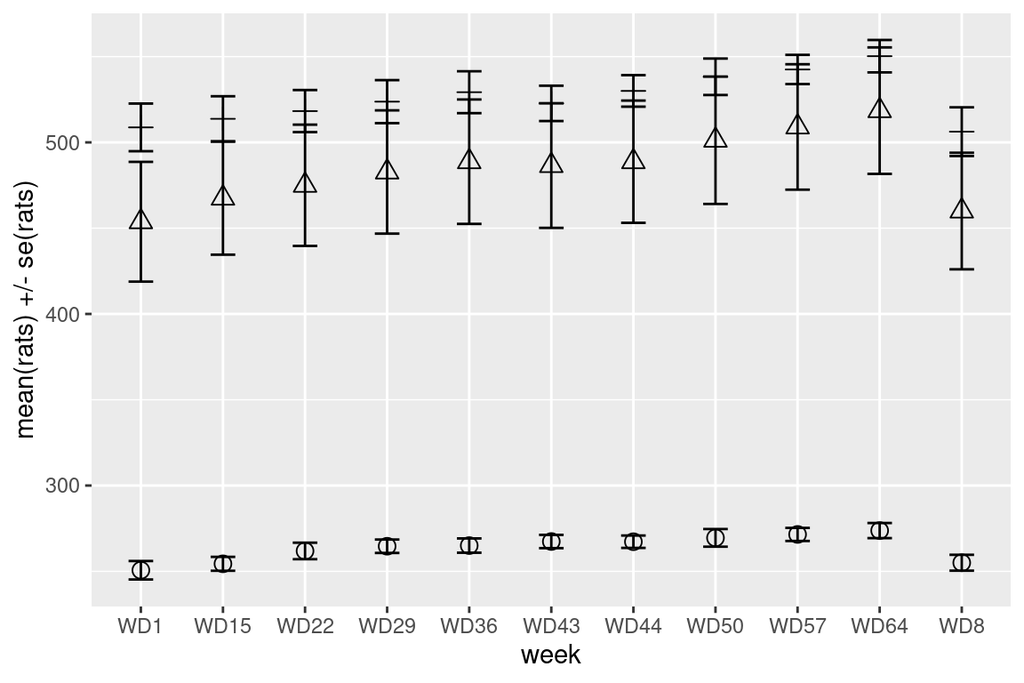

```r
ggplot(RATSS, aes(x = week, y = mean, linetype = Group, shape = Group)) +
  geom_line() +
  scale_linetype_manual(values = c(1,2, 3)) +
  geom_point(size=3) +
  scale_shape_manual(values = c(1,2,3)) +
  geom_errorbar(aes(ymin=mean-se, ymax=mean+se, linetype="1"), width=0.3) +
  theme(legend.position = c(0.8,0.8, 0.8)) +
  scale_y_continuous(name = "mean(rats) +/- se(rats)")
```